# ERS Journal Ranking Tool Update – Methods and Replication Guide

Andrew Crane-Droesch

## Overview

This document details the methods used for combining multiple journal ranking indices into a single index, and describes how we developed tiers based on the index.

We combine six indices from three ranking organizations:

- REPEC Impact factor
- REPEC H-index
- SciImago journal ranking
- SciImago H-index
- Thompson-Reuters impact factor
- Thompson-Reuters eigenfactor

Relatively few of the journals in which ERS has published are ranked in all of these indices, and none of these indices consistently ranks all journals in which ERS has published. This is part of the motivation for combining the rankings into a single index. Another motivation is to correct any bias stemming from missingness in the rankings: probability of absence of a measurement in one index is not uncorrelated with rankings in another index.

As such, combining indices into a single score – using a method that accounts for non-random missingness – aims to simplify journal rankings for ERS’s internal purposes, while rendering disparate journals more comparable. Additionally, the single score takes on a continuous distribution, which contains more information than scores upon which previous journal ranking tools are based. It is hoped that this improves the information environment in which decisions about ERS publication outlets are taken.

Tiers can be created by specifying break points in the score. We specify those break points as the terciles of the distribution of scores in peer-reviewed, rated journals in which ERS has published. Tiers and tier break points are computed separately for economics journals and non-economics journals.

At a high level, we create the score by first predicting the “latent” values of the missing indices, and then computing the principal components of the resultant “filled-in” data. The score is taken as the first principal component of the resultant dataset. We go into further detail below.

## Methods

### Input data

The raw input data (journals in which ERS has published in) looks like this:

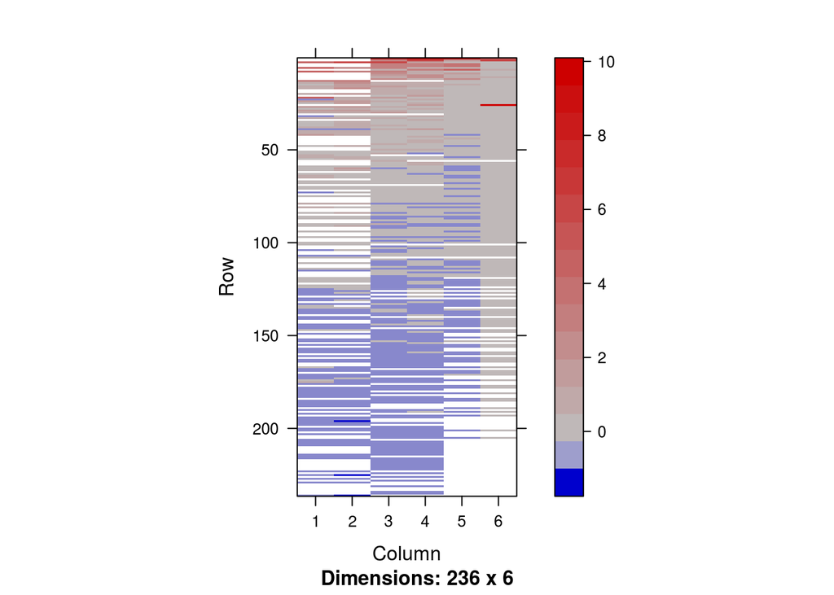

Each column represents one of the indices, and each row represents a journal. The colors represent the logged and normalized index values. Red values are higher values of the indices, which indicate better “quality.” White values indicate missingness.

From this plot, it is clear that

1. Index values are correlated across metrics. Rarely do we see red in one metric and blue in another.
2. If a journal is missing in Thompson-Reuters (the rightmost indices), it is unlikely that it is highly ranked in the other indices.
3. Many high-quality journals are not rankined in REPEC (the leftmost indices).

### Imputation

We use a form of multivariate imputation by chained equations (MICE) to fill in the missing values of indices. The MICE algorithm is fairly simple:

1. For one of several copies of a dataset, randomly fill in missing values from the observed distribution of values of the same variable.
2. For each variable $i$:
- Fit a model $v_i^{obs} = f(v_{-i}^{imp})$, where $obs$ indicates only observed values, and $imp$ indicated both observed and imputed values
- Update predictions of missing values $v_i^{miss} \leftarrow \hat{f}(v_{-i}^{imp})$
- Repeat these steps several times, looping through each variable, until updates approximately converge
3. Because of different initial conditions, results of steps 1 and 2 performed on different datasets will differ slightly. Average them to form a single consensus prediction.

The model that we use for $f()$ is a random forest. Random forests were chosen because they offer good predictive skill with minimal assumpitons about the distribution or other features of the data. In addition to $v_{-i}^{imp}$, we include a matrix of dummy variables in the random forest, of equal dimension to $v_{-i}^{imp}$, equalling 1 where an index value is observed, and 0 otherwise. In this way we make our predictions conditional on the missingness or presence of journal rankings.

This algorithm is run on the full dataset of journals ranked by the three organizations from which we have data. This comprises over 30,000 journals in disparate fields.

The result of the algorithm, applied only to journals within which ERS has published, is below:

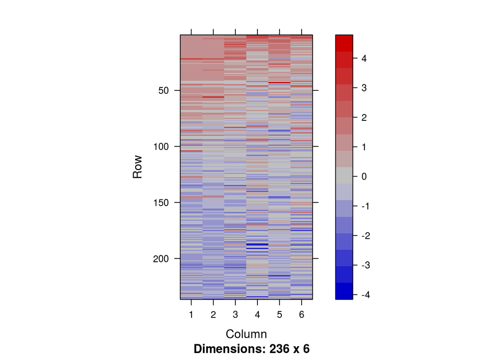

Note that the scale is different; the data are standardized, and the resultant scale reflects the dependence of the standard deviation of each ranking on the number of observations used to comprise it.

### Principal Components Analysis

We perform PCA on the filled-in dataset. The variances of the components are summarized below:

```
## Importance of components:
##                           PC1     PC2     PC3     PC4     PC5     PC6
## Standard deviation     2.3033 0.61496 0.43923 0.25667 0.21459 0.10934
## Proportion of Variance 0.8842 0.06303 0.03215 0.01098 0.00768 0.00199
## Cumulative Proportion  0.8842 0.94720 0.97935 0.99033 0.99801 1.00000
```

The first component accounts for 88% of the variance of the data, and the second only 6%. This first component is well-correlated with individual index scores, where they are observed:

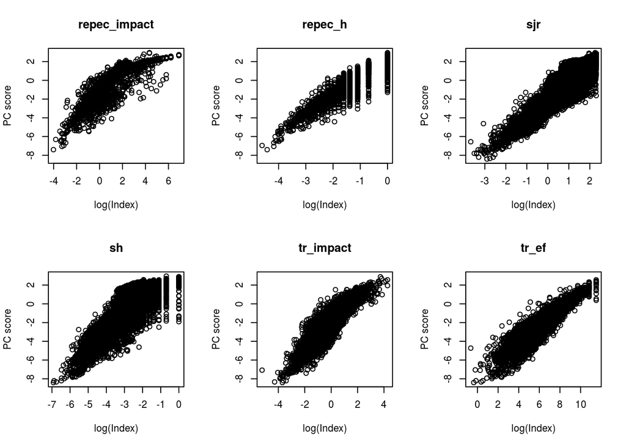

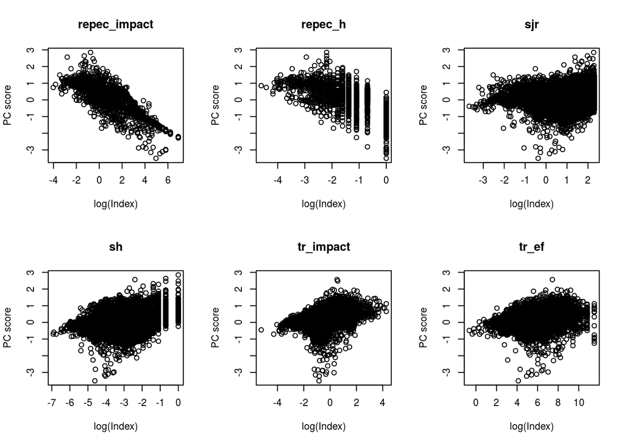

### Tiering

Tiers can be created by drawing lines through the distribution of the PC score. We do so at the terciles of the distribution of the PC score, for journals in which ERS has published. The distribuion of scores for ERS’s past journals, and the cutoff points, are plotted below:

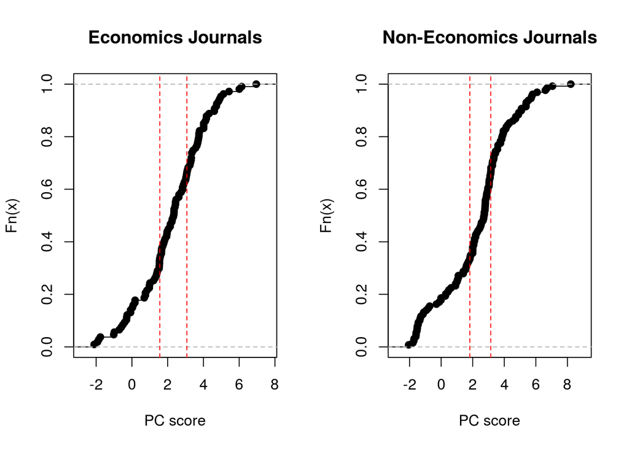